# 2023-06-25-Finance-API-Vignette

Kristina Golden

2023-06-23

This document is a vignette to show how to retrieve data from an API. To show this, I will be using the polygon.io API. Ths API pulls financial information from the stock market.

I will be building functions to pull data from different endpoints of the API.

My functions will use a variety of arguments to get differing return data. All data points include the company’s ticker and the company name. A company can be quiered by their ticket symbol and/or their company name. I have made it so the company name is not case sensitive.

# Required packages

```r
library(httr)
library(jsonlite)
library(tidyverse)
library(kableExtra)
library(ggplot2)
API_KEY <- Sys.setenv("API_KEY" =
                        "_aL5f5EmEje0vL6kYr1xOPtgR8e9rGwT")
```

I used the following packages:

tidyverse: data manipulation and visualization  
jsonlite: API interaction  
httr: API interaction through the GET function  
knitr: displaying tables in a markdown friendly way  
ggplot2: Dynamic graphs

# Functions

Functions created to interact with the API

## `company_quan`

The `company_quan` function allows us to query the API by ticker symbol or company name. The data retrieved is various quantitative data about the company (ie prev day high price).

```r
#Function for company name quantitative
#DONT CHANGE THIS ONE
company_quan <- function(company = "all"){
  url <- "https://api.polygon.io/v2/snapshot/locale/us/markets/stocks/tickers"
  setwd("C:/Users/kmada/OneDrive - Onslow County Schools/3. ST 558/6a. Projects/Project1")
  query_list <- list(apiKey =
                       Sys.getenv("API_KEY"))
  my_data <- GET(url, query = query_list)
  parsed <- fromJSON(rawToChar(my_data$content))
  options <- as.data.frame(parsed$tickers)
  options <- options %>% unnest('day')
      options <- rename(options,
                 Day_Open_Price = o,
                 Day_High_Price = h,
                 Day_Low_Price = l,
                 Day_Close_Price = c,
                 d1 = v,
                 d2 = vw)
      options <- options %>% unnest('prevDay')
      options <- rename(options,
                  Prev_Open_Price = o,
                  Prev_High_Price = h,
                  Prev_Low_Price = l,
                  Prev_Close_Price = c,
                  PerChange_Since_Prev =
                    todaysChangePerc,
                  ValChange_Sine_Prev = todaysChange,
                  d3 = v,
                  d4 = vw)
      options <- options %>% unnest('min')
      options <- as_tibble(options[-c(4, 9:18, 23:24)])
      names <- read.csv("company_names.csv")
      names <- rename(names, ticker = Symbol,
                             name = Name)
      names <- as_tibble(names[-c(3:5)])
      options <- merge(options, names, by = 'ticker')
      options <- options[c(1, 12, 2:11)]

    if (company != "all"){

    if (toupper(company) %in% options$ticker){
      options <- options %>%
        filter(ticker == toupper(company))
    }

    else if (toupper(company) %in% options$Name){
      output <- options %>%
        filter(Name == toupper(company))
    }
    # Otherwise, throw an informative error.
    else {
      message <- paste('ERROR: Argument for company was
                       not found in the ticker or the
                       name column. Returning all
                       companies.')

    }
  }
  # Do nothing if the company value equals "all".
  else {

  output <- as.data.frame(options)
  # Return the output data.frame.
  return(output)
  }
}
c <- company_quan()
```

## `exchange`

The `exchange` function allows us to query the API by which stock exchange we are interested in. The data retrieved are various categorical variables of companies that trade in the queried Stock exchange. (ie type, company name, ticker). Examples of arguments include “xnys”

```r
#Market, locale, primary exchange, type, and currency_name by
#exchange
#DONT CHANGE THIS ONE
exchange <- function(exchange = "all"){
  url <- "https://api.polygon.io/v3/reference/tickers?active=true&limit=1000"
  query_list <- list(apiKey =
                       Sys.getenv("API_KEY"))
  my_data <- GET(url, query = query_list)
  parsed <- fromJSON(rawToChar(my_data$content))
  options <- as.data.frame(parsed$results)
  options$name <- toupper(options$name)
  options$market <- toupper(options$market)
  options <- options[-c(4, 7:12)]

    if (exchange != "all"){

    if (toupper(exchange) %in% options$primary_exchange){
      options <- options %>%
        filter(primary_exchange == toupper(exchange))
    }

    # Otherwise, throw an informative error.
    else {
      message <- paste('ERROR: Argument for exchange was
                       not found in the exchange column.
                       Returning all
                       exchanges')

    }
  }
  # Do nothing if the company value equals "all".
  else {

  output <- as.data.frame(options)
  # Return the output data.frame.
  return(output)
  }
}
e <- exchange('xnys')
```

## `company_cat`

The `company_cat` function allows us to query the API by ticker symbol or company name. The data retrieved is various categorical data about the company (ie stock exchange, type, market). The company name or ticker symbol is the argument.

```r
#Market, locale, primary exchange, type, and currency_name by
#company
company_cat <- function(query = "all") {
  url <- "https://api.polygon.io/v3/reference/tickers"

  query_list <- list(active = "true", limit = 1000, apiKey =
                       Sys.getenv("API_KEY"))

  if (query != "all") {
    query_list$q <- query
  }

  my_data <- GET(url, query = query_list)

  if (http_status(my_data)$category == "Success") {
    parsed <- fromJSON(rawToChar(my_data$content))
    results <- as.data.frame(parsed$results)

    if (nrow(results) > 0) {
      results <-as.data.frame(sapply(results, toupper))
      results <- results[-c(7, 9:12)]
      results <- results %>%
        filter(ticker == toupper(query) |
                 name == toupper(query))
    }
    return(as_tibble(results))

  }
  else {
    stop("Error retrieving data from the API.")
  }
}
```

## `market`

The `market` function allows us to query the API by which market we are interested in. The data retrieved are various categorical variables of companies in a particular market. It’s arguments include OTC and STOCKS. (ie type, company name, ticker, stock exchange).

```r
#Market, locale, primary exchange, type, and currency_name by
#market
market <- function(query = "all") {
  url <- "https://api.polygon.io/v3/reference/tickers"

  query_list <- list(active = "true", limit = 1000, apiKey =
                       Sys.getenv("API_KEY"))

  if (query != "all") {
    query_list$q <- query
  }

  my_data <- GET(url, query = query_list)

  if (http_status(my_data)$category == "Success") {
    parsed <- fromJSON(rawToChar(my_data$content))
    results <- as.data.frame(parsed$results)

    if (nrow(results) > 0) {
      results <-as.data.frame(sapply(results, toupper))
      results <- results[-c(7, 9:12)]
      results <- results %>%
        filter(market == toupper(query))
    }
    return(as_tibble(results))

  }
  else {
    stop("Error retrieving data from the API.")
  }
}
```

## `ticker_type`

The `ticker_type` function allows us to query the API by which type we are interested in. The data retrieved are various categorical variables of companies that trade the queried type. It takes on the arguments CS, UNIT, etc. (ie market, company name, ticker, stock exchange).

```r
#Market, locale, primary exchange, type, and currency_name by
#type
ticker_type <- function(query = "all") {
  url <- "https://api.polygon.io/v3/reference/tickers"

  query_list <- list(active = "true", limit = 1000, apiKey =
                       Sys.getenv("API_KEY"))

  if (query != "all") {
    query_list$q <- query
  }

  my_data <- GET(url, query = query_list)

  if (http_status(my_data)$category == "Success") {
    parsed <- fromJSON(rawToChar(my_data$content))
    results <- as.data.frame(parsed$results)

    if (nrow(results) > 0) {
      results <-as.data.frame(sapply(results, toupper))
      results <- results[-c(7, 9:12)]
      results <- results %>%
        filter(type == toupper(query))
    }
    return(as_tibble(results))

  }
  else {
    stop("Error retrieving data from the API.")
  }
}
```

## `company_comb`

The `company_comb` function combines the quantitative variables and categorical variables for specific companies. It quieries by company name or ticker symbol.

```r
company_comb <- function(company = "all"){
  url <- "https://api.polygon.io/v2/snapshot/locale/us/markets/stocks/tickers"
  query_list <- list(apiKey =
                       Sys.getenv("API_KEY"))
  my_data <- GET(url, query = query_list)
  parsed <- fromJSON(rawToChar(my_data$content))
  options <- as.data.frame(parsed$tickers)
  options <- options %>% unnest('day')
      options <- rename(options,
                 Day_Open_Price = o,
                 Day_High_Price = h,
                 Day_Low_Price = l,
                 Day_Close_Price = c,
                 d1 = v,
                 d2 = vw)
      options <- options %>% unnest('prevDay')
      options <- rename(options,
                  Prev_Open_Price = o,
                  Prev_High_Price = h,
                  Prev_Low_Price = l,
                  Prev_Close_Price = c,
                  PerChange_Since_Prev =
                    todaysChangePerc,
                  ValChange_Sine_Prev = todaysChange,
                  d3 = v,
                  d4 = vw)
      options <- options %>% unnest('min')
      options <- as_tibble(options[-c(4, 9:18, 23:24)])
      cat <- url <- "https://api.polygon.io/v3/reference/tickers"

  query_list <- list(active = "true", limit = 1000, apiKey =
                       Sys.getenv("API_KEY"))
  my_data <- GET(url, query = query_list)
  parsed <- fromJSON(rawToChar(my_data$content))
  options2 <- as.data.frame(parsed$results)
      options2 <- as_tibble(options2[-c(4, 7:12)])
      options <- merge(options, options2, by = 'ticker')
      options <- options[c(1, 12:15, 2:11)]

    if (company != "all"){

    if (toupper(company) %in% options$ticker){
      options <- options %>%
        filter(ticker == toupper(company))
    }

    else if (toupper(company) %in% options$Name){
      output <- options %>%
        filter(Name == toupper(company))
    }
    # Otherwise, throw an informative error.
    else {
      message <- paste('ERROR: Argument for company was
                       not found in the ticker or the
                       name column. Returning all
                       companies.')

    }
  }
  # Do nothing if the company value equals "all".
  else {

  output <- as.data.frame(options)
  # Return the output data.frame.
  return(output)
  }
}
c <- company_comb()
```

## `finAPI`

This function is a wrapper function for all the others above. You simply pass the name of the function you want to use, like “company_comb”, and any additional arguments for that function.

```r
finAPI <- function(func, ...){

  if (func == "company_quan"){
    output <- company_quan(...)
  }
  else if (func == "exchange"){
    output <- exchange(...)
  }
  else if (func == "company_cat"){
    output <- company_cat(...)
  }
  else if (func == "market"){
    output1 <- market('stocks')
    output2 <- market('otc')
    output <- rbind(output1, output2)
  }
  else if (func == "ticker_type"){
    output1 <- ticker_type('CS')
    output2 <- ticker_type('ETF')
    output3 <- ticker_type('UNIT')
    output4 <- ticker_type('ADRC')
    output5 <- ticker_type('ETC')
    output6 <- ticker_type('FUND')
    output7 <- ticker_type('GDR')
    output8 <- ticker_type('OS')
    output9 <- ticker_type('OTHER')
    output10 <- ticker_type('PFD')
    output11 <- ticker_type('RIGHT')
    output12 <- ticker_type('SP')
    output13 <- ticker_type('WARRANT')
    output <- rbind(output1, output2, output3, output4,
                    output5, output6, output7, output8,
                    output9, output10, output11, output12,
                    output13)
  }
  else if (func == "company_comb"){
    output <- company_comb(...)
  }

  else {
    stop("ERROR: Argument for func is not valid!")
  }

  # Return the output from the appropriate function.
  return(output)
}
```

# Data Exploration

Now that we are able to retrieve data from the polygon.io API, we are able to do some data exploration. I will begin by pulling all the different market types. I will do this by `finAPI(‘market’).

```r
fin_market <- finAPI('market')
```

I am interested in market and type. I am interested to see if stocks has the same types as otc. I will compare the frequencies with contingency tables. I am also interested to see if the stock exchange the ticker is traded on has anything to do with the market and type.

```r
#Contingency table for market
market_tab <- addmargins(table(fin_market$market))
names(dimnames(market_tab)) <- c("Market")
market_tab <- knitr::kable((market_tab),
                    caption=paste("Financial Info By Market"))
market_tab
```

Financial Info By Market

| Market | Freq |
| --- | --- |
| OTC | 608 |
| STOCKS | 392 |
| Sum | 1000 |

```r
type_tab <- addmargins(table(fin_market$type))
names(dimnames(type_tab)) <- c("Type")
type_tab <- knitr::kable((type_tab),
                    caption=paste("Financial Info By type"))
type_tab
```

Financial Info By type

| Type | Freq |
| --- | --- |
| ADRC | 89 |
| CS | 398 |
| ETF | 48 |
| ETS | 3 |
| ETV | 1 |
| FUND | 14 |
| GDR | 4 |
| OS | 275 |
| OTHER | 33 |
| PFD | 54 |
| RIGHT | 3 |
| SP | 11 |
| UNIT | 27 |
| WARRANT | 40 |
| Sum | 1000 |

```r
market_type_tab <- addmargins(table(fin_market$type,
                                fin_market$market))
names(dimnames(market_type_tab)) <- c("Type", "Market")
market_type_tab <- knitr::kable((market_type_tab),
                    caption=paste("Financial Info By type and
                                  Market"))
market_type_tab
```

Financial Info By type and Market

|  | OTC | STOCKS | Sum |
| --- | --- | --- | --- |
| ADRC | 72 | 17 | 89 |
| CS | 178 | 220 | 398 |
| ETF | 4 | 44 | 48 |
| ETS | 0 | 3 | 3 |
| ETV | 0 | 1 | 1 |
| FUND | 5 | 9 | 14 |
| GDR | 4 | 0 | 4 |
| OS | 275 | 0 | 275 |
| OTHER | 33 | 0 | 33 |
| PFD | 21 | 33 | 54 |
| RIGHT | 0 | 3 | 3 |
| SP | 1 | 10 | 11 |
| UNIT | 6 | 21 | 27 |
| WARRANT | 9 | 31 | 40 |
| Sum | 608 | 392 | 1000 |

I would like to know on average what are the opening prices of stocks? What are the average closing prices? What about the change in price from one day to the next? The averages of the variables of interest do not exist, therefore I will create them as variables.

I will begin by quering the combined quantitative and categorical variables.

```r
#Create data frame for combined data.

fin_comb <- finAPI('company_comb')
```

```r
#Calculate averages for each quantitative variable
fin_comb <- mutate(fin_comb, AvgPerChange_Since_Prev =
                mean(PerChange_Since_Prev),
              AvgValChange_Since_Prev =
                mean(ValChange_Sine_Prev),
              AvgDay_Open_Price = mean(Day_Open_Price),
              AvgDay_High_Price = mean(Day_High_Price),
              AvgDay_Low_Price = mean(Day_Low_Price),
              AvgDay_Close_Price = mean(Day_Close_Price),
              AvgPrev_Open_Price = mean(Prev_Open_Price),
              AvgPrev_High_Price = mean(Prev_High_Price),
              AvgPrev_Low_Price = mean(Prev_Low_Price),
              AvgPrev_Close_Price = mean(Prev_Close_Price))
fin_comb <- fin_comb[, c(1:5, 6, 16, 7, 17, 8, 18, 9, 19, 10,
                         20, 11, 21, 12, 22, 13, 23, 14, 24,
                         15, 25)]
fin_comb[1:2,]
```

```
##   ticker                      name market primary_exchange type
## 1      A Agilent Technologies Inc. stocks             XNYS   CS
## 2     AA         Alcoa Corporation stocks             XNYS   CS
##   PerChange_Since_Prev AvgPerChange_Since_Prev ValChange_Sine_Prev
## 1            0.6235254              -0.5144377                0.74
## 2           -2.0652499              -0.5144377               -0.69
##   AvgValChange_Since_Prev Day_Open_Price AvgDay_Open_Price Day_High_Price
## 1              -0.2787398         117.76          27.94707         119.71
## 2              -0.2787398          32.73          27.94707          33.30
##   AvgDay_High_Price Day_Low_Price AvgDay_Low_Price Day_Close_Price
## 1          28.22699        117.58         27.65474          119.42
## 2          28.22699         32.55         27.65474           32.84
##   AvgDay_Close_Price Prev_Open_Price AvgPrev_Open_Price Prev_High_Price
## 1           27.89395          118.84           28.37596          118.95
## 2           27.89395           33.80           28.37596           33.95
##   AvgPrev_High_Price Prev_Low_Price AvgPrev_Low_Price Prev_Close_Price
## 1           28.64694         117.17          28.06147           118.68
## 2           28.64694          32.81          28.06147            33.41
##   AvgPrev_Close_Price
## 1            28.41585
## 2            28.41585
```

This allows me to see that on average, the percent change since the previous is negative, therefore indicating a fall in price.

I would like to graphically compare the different types by which stock exchange it is traded on. I will do this with a barchart.

I will begin by quering from the API by ticker_type.

```r
#Query by ticker_type
types <- finAPI('ticker_type')
```

I will then create a barchart that allows me to compare the different types based on what stock exchange they are traded on.

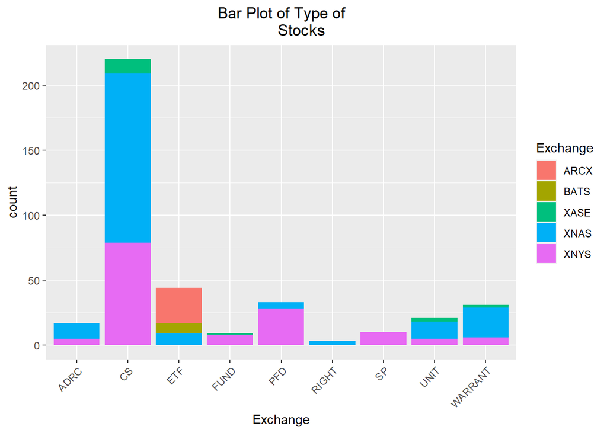

```r
#Barchart for type
types <- types %>% drop_na(primary_exchange)
g <- ggplot(types, aes(x = type))
g <- g + geom_bar(aes(fill = as.factor(primary_exchange))) +
    labs(x = "Exchange", title = "Bar Plot of Type of
         Stocks") +
    scale_x_discrete(guide = guide_axis(angle = 45)) +
    scale_fill_discrete(name = 'Exchange') +
    theme(plot.title=element_text(hjust=0.5))
g
```

I quickly see that CS is traded mainly on the XNYS and XNAS exchanges. I can also see the only type the ARCX trades is the ETF.

I would like to compare day low price by which stock exchange it is traded with I will do this through a histogram. I will begin by creating a dataframe with the combined quantitative and categorical variables.

```r
#Create dataframe
fin_comb <- finAPI("company_comb")
```

I will then create a histogram.

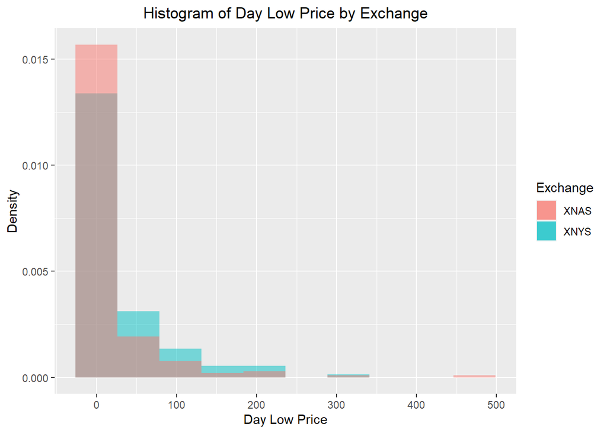

```r
#Histogram between day low price and exchange
g <- ggplot(fin_comb, aes(Day_Low_Price,
                          y=after_stat(density),
                          fill=primary_exchange)) +
  # Add a semi-transparent histogram with 10 bins for XNYS.
  geom_histogram(data=subset(fin_comb,
                             primary_exchange == 'XNYS'),
                              bins=10, alpha = 0.5) +
  # Add a semi-transparent histogram with 10 bins for XNAS.
  geom_histogram(data=subset(fin_comb,
                             primary_exchange =='XNAS'),
                             bins=10, alpha = 0.5) +
  # Add a better legend label.
  guides(fill=guide_legend(title="Exchange")) +
  # Add labels to the axes.
  scale_x_continuous("Day Low Price") +
  scale_y_continuous("Density") +
  # Add a title.
  ggtitle("Histogram of Day Low Price by Exchange") +
  theme(plot.title=element_text(hjust=0.5))
g
```

This histogram shows that both the day low price for XNAS and XNYS are skewed to the right. I can also see that XNAS has a higher density of the lower day low price.

I wiould like to compare the percent change since the previous day by which type a company is traded as. I will use the same data base created previously.

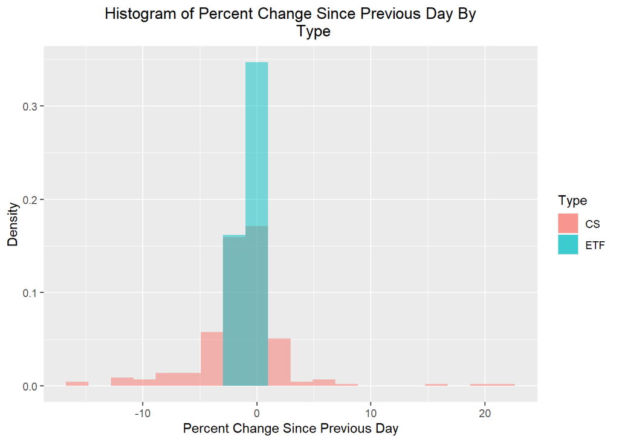

```r
#Histogram between percent change since previous day and Type.
fin_comb <- finAPI("company_comb")

#Histogram for type
g <- ggplot(fin_comb, aes(PerChange_Since_Prev,
                          y=after_stat(density),
                          fill=type)) +
  # Add a semi-transparent histogram with 10 bins for XNYS.
  geom_histogram(data=subset(fin_comb,
                             type == 'CS'),
                              bins=20, alpha = 0.5) +
  # Add a semi-transparent histogram with 10 bins for XNAS.
  geom_histogram(data=subset(fin_comb,
                             type =='ETF'),
                             bins=20, alpha = 0.5) +
  # Add a better legend label.
  guides(fill=guide_legend(title="Type")) +
  # Add labels to the axes.
  scale_x_continuous("Percent Change Since Previous Day") +
  scale_y_continuous("Density") +
  # Add a title.
  ggtitle("Histogram of Percent Change Since Previous Day By
          Type") +
  theme(plot.title=element_text(hjust=0.5))
g
```

I can quickly see that the ETF has a much smaller variation than the CS.

To compare day high price between exchanges, I will use a boxplot. I will continue to use the same data frame from before.

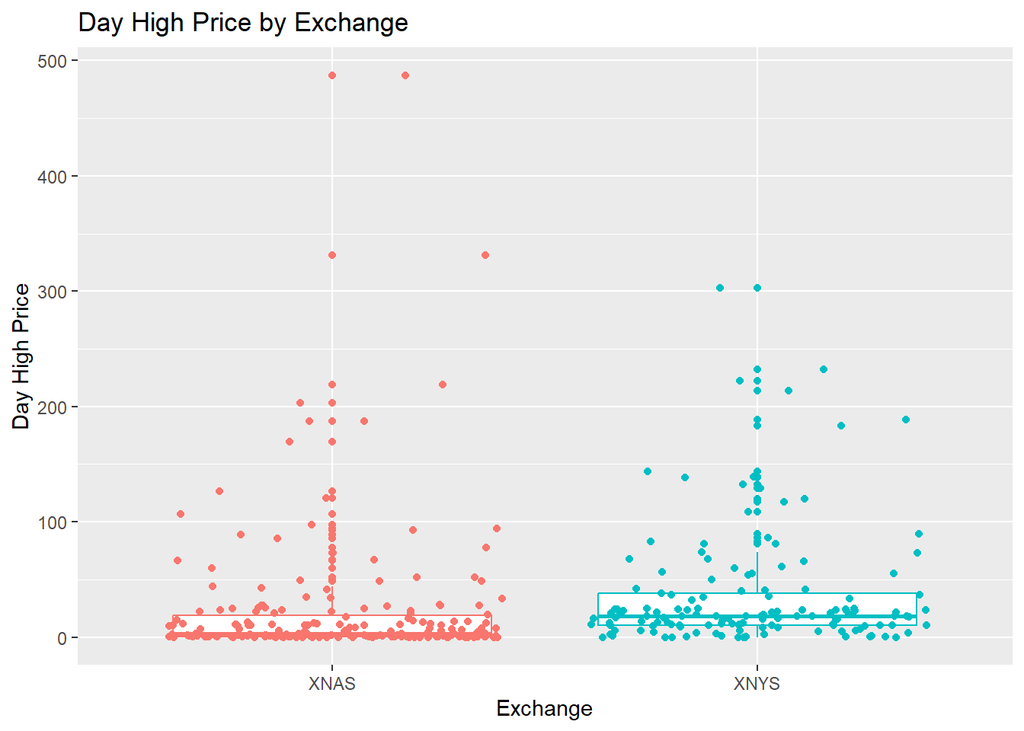

```r
#Boxplot for Day High Price for XNAS and XNYS
fin_comb <- subset(fin_comb, primary_exchange == 'XNYS' |
                     primary_exchange == 'XNAS')
g <- ggplot(fin_comb,
               aes(primary_exchange,
                   Day_High_Price,
                   color=primary_exchange)) +
  # Add the box plot layer.
  geom_boxplot() +
  # Jitter the points to add a little more info to the boxplot.
  geom_jitter() +
  # Add labels to the axes.
  scale_x_discrete("Exchange") +
  scale_y_continuous("Day High Price") +
  # Add a title.
  ggtitle("Day High Price by Exchange") +
  # Remove the legend because it isn't needed.
  theme(legend.position="none")

# Display the plot.
g
```

I can see that both exchanges have majority of their day high prices at relatively low values, but they both have several upper outliers, with XNAS being the higher of the two. XYS has a larger IQR than XNAS.

I suspect their is a strong, positive linear relationship between day low price and day high price. It would stand to reason that if the day price begins high, then the price at the end of the day would also be high. To visually investigate this, with no statistical significance, I will create a scatterplot between the two variables. I will continue to use the data frame from before.

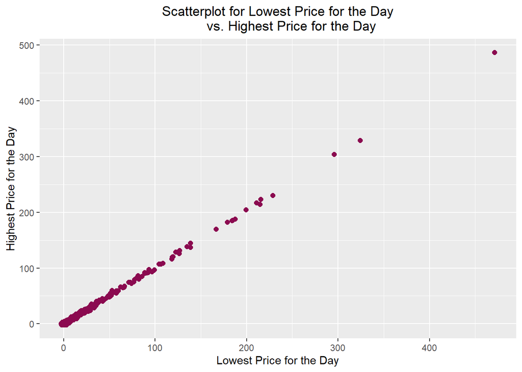

```r
#Scatterplot for Scatterplot for Lowest Price for the Day
#vs. Highest Price for the Day
fin_com <- company_comb()
ggplot(fin_com, aes(x=Day_Low_Price, y=Day_High_Price)) +
  geom_point(size = 2,
             position=position_jitter(width=3,height=2), color
             = '#8b0a50') +
  xlab('Lowest Price for the Day') +
  ylab('Highest Price for the Day') +
  labs(title = 'Scatterplot for Lowest Price for the Day
       vs. Highest Price for the Day') +
  theme(plot.title=element_text(hjust=0.5))
```

My suspicians have been visually confirmed.

I would like to summarize the day open price by type. I will do this through the 5 number summary. I will continue to use my data frame created earlier.

```r
#Summarize Day Open Price by type
fin_comb <- finAPI('company_comb')
Open_FiveNum <- fin_comb %>%
  # Select the type and price columns.
  select(type, Day_Open_Price) %>%
  # Group by type.
  group_by(type) %>%
  # Get summary statistics for price.
  summarize("Min." = min(Day_Open_Price),
            "Q1" = quantile(Day_Open_Price, 0.25,
                                      na.rm=TRUE),
            "Median" = quantile(Day_Open_Price, 0.5,
                                na.rm=TRUE),
            "Q3" = quantile(Day_Open_Price, 0.75,
                                      na.rm=TRUE),
            "Max" = max(Day_Open_Price))

Open_FiveNum <- knitr::kable(Open_FiveNum,
             caption="Five-Number Summary for Day Open Price
             by Type",
             digits=2)
Open_FiveNum
```

Five-Number Summary for Day Open Price by Type

| type | Min. | Q1 | Median | Q3 | Max |
| --- | --- | --- | --- | --- | --- |
| ADRC | 0.00 | 0.96 | 1.15 | 2.27 | 22.26 |
| CS | 0.00 | 2.17 | 10.49 | 39.99 | 472.95 |
| ETF | 8.43 | 23.93 | 30.51 | 46.51 | 107.19 |
| ETS | 20.95 | 24.06 | 27.16 | 27.24 | 27.31 |
| ETV | 26.36 | 26.36 | 26.36 | 26.36 | 26.36 |
| FUND | 5.17 | 9.44 | 12.37 | 16.43 | 19.37 |
| PFD | 0.00 | 17.55 | 19.76 | 22.65 | 25.55 |
| RIGHT | 0.00 | 0.00 | 0.00 | 0.10 | 0.21 |
| SP | 17.92 | 20.99 | 23.59 | 24.31 | 81.21 |
| UNIT | 0.00 | 0.00 | 0.00 | 10.42 | 11.20 |
| WARRANT | 0.00 | 0.01 | 0.06 | 0.12 | 0.98 |

I would like to summarize the day open price by exchange. I will do this through the 5 number summary. I will continue to use my data frame created earlier.

```r
#Summarize Day Open Price by Exchange
fin_comb <- finAPI('company_comb')
Open_FiveNum <- fin_comb %>%
  # Select the type and price columns.
  select(primary_exchange, Day_Open_Price) %>%
  # Group by type.
  group_by(primary_exchange) %>%
  # Get summary statistics for price.
  summarize("Min." = min(Day_Open_Price),
            "Q1" = quantile(Day_Open_Price, 0.25,
                                      na.rm=TRUE),
            "Median" = quantile(Day_Open_Price, 0.5,
                                na.rm=TRUE),
            "Q3" = quantile(Day_Open_Price, 0.75,
                                      na.rm=TRUE),
            "Max" = max(Day_Open_Price))

Open_FiveNum <- knitr::kable(Open_FiveNum,
             caption="Five-Number Summary for Day Open Price
             by Exchange",
             digits=2)
Open_FiveNum
```

Five-Number Summary for Day Open Price by Exchange

| primary_exchange | Min. | Q1 | Median | Q3 | Max |
| --- | --- | --- | --- | --- | --- |
| ARCX | 13.43 | 23.93 | 26.17 | 40.27 | 107.19 |
| BATS | 8.43 | 11.63 | 24.96 | 38.32 | 97.32 |
| XASE | 0.00 | 0.00 | 3.35 | 11.20 | 56.49 |
| XNAS | 0.00 | 0.56 | 2.82 | 19.12 | 472.95 |
| XNYS | 0.00 | 10.19 | 18.16 | 38.08 | 300.02 |

# Wrap-up

To summarize everything I did in this vignette, I began by building functions to interact with some of the polygon.io’s API’s endpoints. I used the endpoints to create tables, data.frames, bar graphs, histograms, boxplots, and a scatterplot. I also created a variable for the averages of the quantitative variables. I was able summarize different quantitative variables by categorical variables.

Most importantly, I hope my code helps you with interacting with APIs!